# Final320 Project

#### Motivation

The reason why I have chosen to do an analysis on Hearthstone is because it is a game that I am familiar with as a former player. Its a card game developed by Blizzard Games taking inspiration from its World of Warcraft characters and mosnters. The data is from originally Hearthpwn, a website in which users can post decks and guides. From this data I hope to be able to analyze card popularity as well as the meta at the time.

#### Libraries used

I am using numpy to do calculations

I am using pandas to convert the csv files into pandas dataframe

I am using pyplot to visualize data

I am using seaborn to visualize data

I am using sklearn to do machine learning on the data

```python
import numpy as np
import pandas as pd
import matplotlib.pyplot as plt
import seaborn as sns
from sklearn.neural_network import MLPRegressor

# Import necessary modules
from sklearn.model_selection import train_test_split
from sklearn.metrics import mean_squared_error
from math import sqrt
from sklearn.metrics import r2_score
from sklearn.neural_network import MLPClassifier
from sklearn.metrics import classification_report,confusion_matrix
from sklearn.datasets import make_classification
from sklearn.metrics import plot_confusion_matrix
from sklearn.model_selection import train_test_split
from sklearn.svm import SVC

from sklearn import preprocessing
from sklearn.model_selection import KFold
from sklearn.linear_model import LinearRegression
import warnings
warnings.filterwarnings("ignore")
```

#### Data explanation

The website can be found at https://www.hearthpwn.com/

```python
df = pd.read_csv("/Users/kevintat/Downloads/archive-1/data.csv")

cards = pd.read_json("/Users/kevintat/Downloads/archive-1/refs.json")
cards = cards.replace(np.nan, 0)

cards.head()
```

|  | artist | attack | cardClass | collectible | cost | dbfId | flavor | health | id | name | ... | targetingArrowText | durability | entourage | faction | overload | spellDamage | hideStats | classes | multiClassGroup | collectionText |
| --- | --- | --- | --- | --- | --- | --- | --- | --- | --- | --- | --- | --- | --- | --- | --- | --- | --- | --- | --- | --- | --- |
| 0 | Jakub Kasper | 4.0 | NEUTRAL | 1.0 | 4.0 | 2518.0 | The crowd ALWAYS yells lethal. | 4.0 | AT_121 | Crowd Favorite | ... | 0 | 0.0 | 0 | 0 | 0.0 | 0.0 | 0.0 | 0 | 0 | 0 |
| 1 | 0 | 4.0 | NEUTRAL | 0.0 | 6.0 | 1769.0 | 0 | 7.0 | CRED_09 | Ben Thompson | ... | 0 | 0.0 | 0 | 0 | 0.0 | 0.0 | 0.0 | 0 | 0 | 0 |
| 2 | 0 | 0.0 | NEUTRAL | 0.0 | 0.0 | 10081.0 | 0 | 0.0 | TB_007e | Deviate Switch | ... | 0 | 0.0 | 0 | 0 | 0.0 | 0.0 | 0.0 | 0 | 0 | 0 |
| 3 | Mauricio Herrera | 3.0 | WARRIOR | 1.0 | 3.0 | 40569.0 | "I don't know a lot about used GvG cards, so I... | 3.0 | CFM_755 | Grimestreet Pawnbroker | ... | 0 | 0.0 | 0 | 0 | 0.0 | 0.0 | 0.0 | 0 | 0 | 0 |
| 4 | Ittoku | 2.0 | NEUTRAL | 1.0 | 4.0 | 1370.0 | His dreams of flying and breathing fire like h... | 7.0 | CS2_119 | Oasis Snapjaw | ... | 0 | 0.0 | 0 | 0 | 0.0 | 0.0 | 0.0 | 0 | 0 | 0 |

5 rows × 32 columns

#### Cleaning the data

The data I want to look at for this tutorial is the standard meta which contains cards from sets released 2 years ago to the present which in this case is 2016. I do so by making sure the deck format is only standard. The reason why I want to look at standard is because as a newer player it is harder to get into Wild, a format that includes all the sets, because the cards in some Wild decks require the purchase of sets that cannot be played in any format and most of the good decks in the Wild format are expensive to make

```python
df = df[df['deck_format'] == "S"]
df = df[df["deck_type"] == "Ranked Deck"]
df = df[df["deck_set"] == "Explorers"]
df.head()
```

|  | craft_cost | date | deck_archetype | deck_class | deck_format | deck_id | deck_set | deck_type | rating | title | ... | card_20 | card_21 | card_22 | card_23 | card_24 | card_25 | card_26 | card_27 | card_28 | card_29 |
| --- | --- | --- | --- | --- | --- | --- | --- | --- | --- | --- | --- | --- | --- | --- | --- | --- | --- | --- | --- | --- | --- |
| 11 | 0 | 2016-02-19 | Unknown | Mage | S | 432989 | Explorers | Ranked Deck | 2 | Beginners Spelldamage Mage | ... | 662 | 662 | 672 | 672 | 906 | 906 | 1004 | 1004 | 1084 | 1084 |
| 19 | 5180 | 2016-02-19 | Unknown | Rogue | S | 432978 | Explorers | Ranked Deck | 1 | Weazelbuster's Storm Rogue (Standard) | ... | 1029 | 1064 | 1117 | 1117 | 1158 | 1158 | 268 | 556 | 2884 | 2884 |
| 31 | 6260 | 2016-02-19 | Unknown | Druid | S | 432954 | Explorers | Ranked Deck | 1 | Ramp Druid | ... | 2598 | 2598 | 2736 | 2782 | 2782 | 2919 | 38113 | 38113 | 38319 | 38319 |
| 58 | 7980 | 2016-02-19 | Fatigue Mage | Mage | S | 432916 | Explorers | Ranked Deck | 1 | K-DOG's Malygos Fatigue Mage: Wrecker of Contr... | ... | 1016 | 2262 | 2874 | 2875 | 2901 | 2901 | 2949 | 36111 | 39225 | 39840 |
| 98 | 1480 | 2016-02-19 | Mill Rogue | Rogue | S | 432849 | Explorers | Ranked Deck | 2 | Mill Rogue Revived! (K-DOG) | ... | 2291 | 2304 | 2304 | 2704 | 2883 | 2949 | 2951 | 38578 | 39313 | 39491 |

5 rows × 41 columns

#### Data analysis and Visualization

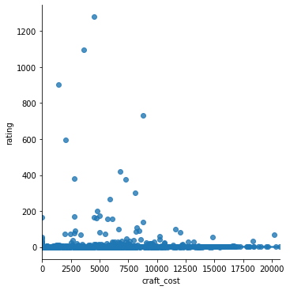

```python
sns.lmplot(data=df, x="craft_cost", y="rating")
```

Dust in this case is the currency used to craft cards. Common cards craft for 40 dust, rare for 100 dust, epic for 400 dust, and legendary for 1600 dust.

A deck is constructed of 30 of these cards. The reason why we see outrageously expensive crafting costs are perhaps theory crafted decks or joke decks posted on Hearthpwn.

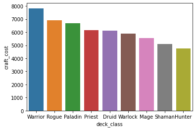

```python
class_cost = df.groupby("deck_class", as_index = False)["craft_cost"].mean().sort_values(by ='craft_cost', ascending= False)
sns.barplot(x="deck_class", y="craft_cost", data=class_cost)
```

Looking at the average cost distribution of deck costs for classes it matches the class identity that blizzard ascribed to the classes. Generally warrior decks are costly because the class identity for warrior is control. Control is a playstyle in which the cards in your deck are made to "control" the board. This usually includes but is not limited to board wipes and minion removal spells. Since board wipes and minion removal spells are efficient, they remove minions that cost more mana than the removal spell to summon. Warriors often run expensive finisher cards to win the game once they clear the board. Hunter on the other hand plays an aggressive style. Normally the mana costs of the cards that hunter decks run are cheap because the game plan for a hunter is to set up a board and rush the opponent down before the opponent can set up a defense. Hunters run a more minion heavy deck with a few finisher spells while warriors run a spell heavy deck with big minion finishers. Quite the opposite playstyle.

To learn more about class identity follow this link https://playhearthstone.com/en-us/news/23014810

To learn more about deck playstyles follow this link https://hearthstone.fandom.com/wiki/Deck_type

```python
class_popularity = df.groupby("deck_class",as_index=False)["rating"].sum().sort_values(by='rating', ascending=False)
class_popularity
```

|  | deck_class | rating |
| --- | --- | --- |
| 6 | Shaman | 2954 |
| 2 | Mage | 2298 |
| 1 | Hunter | 2094 |
| 5 | Rogue | 1885 |
| 0 | Druid | 1749 |
| 7 | Warlock | 1556 |
| 4 | Priest | 1483 |
| 8 | Warrior | 1285 |
| 3 | Paladin | 842 |

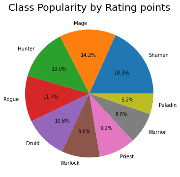

```python
plt.figure(figsize=(6,6))
plt.title('Class Popularity by Rating points', fontsize=20)
plt.pie(class_popularity.rating, labels=class_popularity.deck_class, autopct='%1.1f%%')
plt.show()
```

The reason why I am using a pie chart to visualize my data here is because the whole pie represents the standard meta. It is easy to see here that Shaman represents a large portion of the meta.

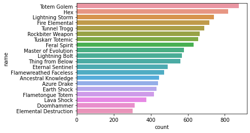

```python
shaman = df[df['deck_class'] == "Shaman"].sort_values(by=['rating'], ascending= False)
shaman.head()

card = {}
for index, row in shaman.iterrows():
    card[row.card_0] = card.get(row.card_0, 0) + 1
    card[row.card_1] = card.get(row.card_1, 0) + 1
    card[row.card_2] = card.get(row.card_2, 0) + 1
    card[row.card_3] = card.get(row.card_3, 0) + 1
    card[row.card_4] = card.get(row.card_4, 0) + 1
    card[row.card_5] = card.get(row.card_5, 0) + 1
    card[row.card_6] = card.get(row.card_6, 0) + 1
    card[row.card_7] = card.get(row.card_7, 0) + 1
    card[row.card_8] = card.get(row.card_8, 0) + 1
    card[row.card_9] = card.get(row.card_9, 0) + 1
    card[row.card_10] = card.get(row.card_10, 0) + 1
    card[row.card_11] = card.get(row.card_11, 0) + 1
    card[row.card_12] = card.get(row.card_12, 0) + 1
    card[row.card_13] = card.get(row.card_13, 0) + 1
    card[row.card_14] = card.get(row.card_14, 0) + 1
    card[row.card_15] = card.get(row.card_15, 0) + 1
    card[row.card_16] = card.get(row.card_16, 0) + 1
    card[row.card_17] = card.get(row.card_17, 0) + 1
    card[row.card_18] = card.get(row.card_18, 0) + 1
    card[row.card_19] = card.get(row.card_19, 0) + 1
    card[row.card_20] = card.get(row.card_20, 0) + 1
    card[row.card_21] = card.get(row.card_21, 0) + 1
    card[row.card_22] = card.get(row.card_22, 0) + 1
    card[row.card_23] = card.get(row.card_23, 0) + 1
    card[row.card_24] = card.get(row.card_24, 0) + 1
    card[row.card_25] = card.get(row.card_25, 0) + 1
    card[row.card_26] = card.get(row.card_26, 0) + 1
    card[row.card_27] = card.get(row.card_27, 0) + 1
    card[row.card_28] = card.get(row.card_28, 0) + 1
    card[row.card_29] = card.get(row.card_29, 0) + 1

card_data = pd.DataFrame(list(card.items()),columns = ['dbfId','count']).sort_values(by=['count'], ascending= False )
card_data.head()

shaman_pop = pd.merge(card_data, cards, on= "dbfId")[["name", "count"]].sort_values(by = ["count"], ascending= False)
g = sns.barplot(x= "count", y= "name", data= shaman_pop.head(20))
```

The reason why I decided to show the top 20 cards is because the way deck making works is that you are able to put up to 2 copies of any non-legendary card. Since the any card in the top 20 is worth an extra copy in the deck this would be the typical inclusion of your average shaman deck.

The reason why I chose to represent the data as a bar plot is to show the differences in card popularity between each of the shaman cards.

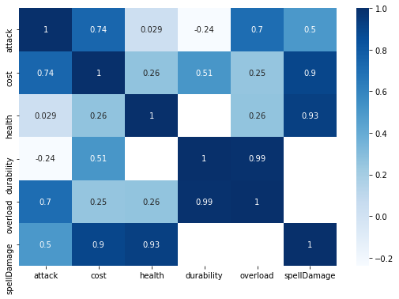

```python
corr_df = pd.merge(card_data, cards, on= "dbfId").drop(['collectible', 'elite', 'hideStats', 'count', 'dbfId'], axis=1)
plt.figure(figsize=(9,6))
sns.heatmap(corr_df.corr(), annot=True, cmap='Blues')
plt.show()
```

According to this correlation matrix we can see that cards with the keyword "overload" generally have low mana costs but high overall health and attack stats. This means that the minions that shamans run in their decks are extremely mana efficient for their costs at least on paper. The way the overload mechanic works is that the player pays a small mana cost on the turn they play the card however they lose X mana to play with next turn. Think of it as a borrowing money to play the card. Eventually you have to pay the money back next turn.

```
(2181, 2)
(936, 2)
```

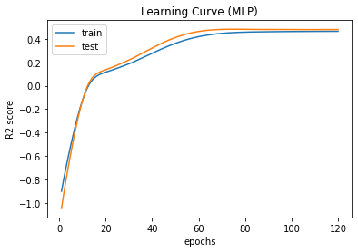

```python
df = cards[["health", "attack", "cost"]]
target_column = ['cost']
predictors = list(set(list(df.columns))-set(target_column))
df[predictors] = df[predictors]/df[predictors].max()
df.describe().transpose()
X = df[predictors].values
y = df[target_column].values

X_train, X_test, y_train, y_test = train_test_split(X, y, test_size=0.30, random_state=40)
print(X_train.shape); print(X_test.shape)

#mlp.score(X_test, y_test)

def iterative_fit(algorithm, X_train, y_train, X_test, y_test, max_epochs):
    model = algorithm
    scores = {'train':[], 'test':[]}
    for i in range(max_epochs):# fit 1 epoch (=1 iteration through whole dataset)
        model.partial_fit(X_train, y_train)
        train_score = model.score(X_train, y_train)
        test_score = model.score(X_test, y_test)
        scores['train'].append(train_score)
        scores['test'].append(test_score)
    return scores, model

algorithm = MLPRegressor(random_state=42)
iterative_scores, mlp_model = iterative_fit(algorithm, X_train, y_train, X_test, y_test, max_epochs=120)


#print(iterative_scores)

epochs = range(1, len(iterative_scores['train'])+1)
plt.plot(epochs, iterative_scores['train'], label='train')
plt.plot(epochs, iterative_scores['test'], label='test')
plt.title('Learning Curve (MLP)')
plt.xlabel('epochs')
plt.ylabel('R2 score')
plt.legend()
plt.show()
```

#### Conclusions

Recap: We looked at the correlation between rating and crafting costs for decks and found that there is no correlation. Then we looked at the average cost expidenture for each class. Next we looked at the class popularity and found that Shaman was the most popular class at the time. We then took a closer look at the deck composition of the average Shaman deck and found that the most popular cards for shaman are extremely mana efficient for their statlines and effects. Finally we looked at the stat lines of minions and tried to predict the mana cost of each card. While the results were not the best they it is understandable as calculating the cost of a card goes beyond looking at the statline of a card but rather the effect it has when it enters or leaves the field.

You can play hearthstone by first downloading the blizzard client launcher at https://playhearthstone.com/en-us

How many Blizzard employees do you need to fix a lamp? It does not matter, because they cannot balance the ladder.